# Predicting Social Media Shares of Mashable News Articles

STAT 301-2 Final Project

Author

Stacy Caeiro

Published

March 12, 2024

**Github Repo Link**

[Final-Project-Github-Link](https://github.com/stat301-2-2024-winter/final-project-2-stacycaeiro.git)

## Introduction

My prediction problem is to predict the amount of social media shares that an online article with receive. I am choosing this problem because increasing social media shares is a common business goal. Thus, the results of this model can act as a guide to other publishing sities on how to increase their social media visibility.

I will be using the [Online News Popularity](https://archive.ics.uci.edu/dataset/332/online+news+popularity) from the [UC Irvine Machine Learning Repository](https://archive.ics.uci.edu/). This dataset contains features of Mashable news articles published over a 2 year period, such as length of title and day of the week published.

## Data Overview

### Target Variable Analysis

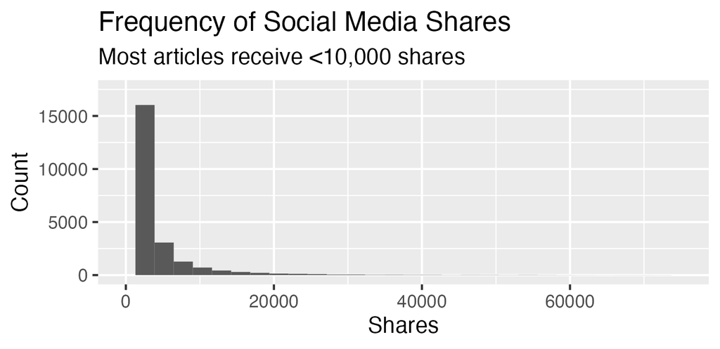

Table 1: Summary Statistics for Shares

| min | q1 | median | q3 | max | sd |
| --- | --- | --- | --- | --- | --- |
| 1 | 946 | 1400 | 2800 | 843300 | 11626.95 |

Furthermore, as seen in Table 1, the minimum value of shares is 1, the 25th quantile is 946, the median is 1400, the 75th quantile is 2800, the maximum value is 843,300, and the standard deviation is 11,627. While there are major outliers on both sides of the dataset, the middle 50% of articles receive 946-2800 shares. However, the standard deviation is large due to the high end outliers.

### Exploratory Data Analysis

For starters, the entire dataset contains no missing values.

Furthermore, upon analysis of a subset of the dataset, which contained 80% of the training data, the following trends were discovered: 1. There are correlations between predictor variables in the dataset, such as between number of links and number of images in an article 2. Multiple variables, such as number of tokens of content and shares of best keyword, are right skewed 3. Multiple variables, such as title and global sentiment polarity, have a non-linear relationship.

I added specific pre-processing steps to my feature engineering recipes to address these trends and make a more efficient model. The graphs supporting these trends are showcased in Appendix I.

## Methods

### Data Splitting & Folding

For this predictive model, I will be conducting a regression analysis because the target outcome is a numeric variable.

I have chosen to conduct v-fold cross-validation in order to mitigate the risk of overfitting the model. I used an 80-20 data split because my dataset has 39k observations, so using 20% of the dataset for testing will provide enough observations for sufficient testing but not so many observations that the model is overfit. Additionally, I used stratified sampling on the target variable shares in order to ensure a balanced distribution of the target variables within all of the folds. Furthermore, I used 5 folds and 3 repeats. I chose these values because 5 fold and 3 repeats allows for a sufficient amount of models to be trained, but low enough the maintain a reasonable computational speed and efficiency.

### Models & Tuning

I tuned and fit 6 types of models: null, linear, elastic net, random forest, k-nearest neighbors, and boosted tree.

Here are the parameters I have tuned per model: 1. Null - no tuning 2. Linear - no tuning 3. Elastic Net - tuned penalty and mixture 4. Random Forest - tuned number of variables sampled at each split and minimum number of observations per node 5. K-Nearest Neighbors - tuned number of neighbors 6. Boosted Tree - tuned number of variables sampled at each split, minimum number of observations per node, and learn rate

Furthermore, I tuned my models using a regular grid with 5 levels to explore a variety of ranges of hyperparameter pairings while still maintaining reasonable computational speed and efficiency.

### Recipes

I ran each model twice, one on a kitchen sink recipe and one on a feature engineering recipe. I had 4 total recipes: a kitchen sink recipe for non-tree models, a kitchen sink recipe for tree models, a feature engineering recipe for non-tree models, and a feature engineering recipe for tree models.

The EDA behind these preprocessing steps is showcased in Appendix I.

### Metric

I am using Root Mean Square Error (RMSE) as my final metric because it provides an easily understandable measure of the average prediction error of the model.

## Model Building and Selection

Table 2: RMSE of all Models

| .metric | .estimator | mean | n | std_err | .config | Model | penalty | mixture | mtry | min_n | neighbors | learn_rate |
| --- | --- | --- | --- | --- | --- | --- | --- | --- | --- | --- | --- | --- |
| rmse | standard | 0.8474859 | 15 | 0.0018340 | Preprocessor1_Model02 | Random Forest (Basic) | NA | NA | 9 | 2 | NA | NA |
| rmse | standard | 0.8499987 | 15 | 0.0018009 | Preprocessor1_Model07 | Random Forest | NA | NA | 9 | 11 | NA | NA |
| rmse | standard | 0.8530368 | 15 | 0.0015703 | Preprocessor1_Model123 | Boosted Tree (Basic) | NA | NA | 25 | 40 | NA | 0.3162278 |
| rmse | standard | 0.8537809 | 15 | 0.0019675 | Preprocessor1_Model119 | Boosted Tree | NA | NA | 37 | 30 | NA | 0.3162278 |
| rmse | standard | 0.8759775 | 15 | 0.0039934 | Preprocessor1_Model19 | Elastic Net (Basic) | 0.0031623 | 0.7625 | NA | NA | NA | NA |
| rmse | standard | 0.8759775 | 15 | 0.0039934 | Preprocessor1_Model19 | Elastic Net (Basic) | 0.0031623 | 0.7625 | NA | NA | NA | NA |
| rmse | standard | 0.8972666 | 15 | 0.0017190 | Preprocessor1_Model05 | Elastic Net | 1.0000000 | 0.0500 | NA | NA | NA | NA |
| rmse | standard | 0.8972666 | 15 | 0.0017190 | Preprocessor1_Model05 | Elastic Net | 1.0000000 | 0.0500 | NA | NA | NA | NA |
| rmse | standard | 0.8995126 | 15 | 0.0014692 | Preprocessor1_Model5 | K-Nearest Neighbors | NA | NA | NA | NA | 15 | NA |
| rmse | standard | 0.9097062 | 15 | 0.0019934 | Preprocessor1_Model5 | K-Nearest Neighbors (Basic) | NA | NA | NA | NA | 15 | NA |
| rmse | standard | 0.9280840 | 15 | 0.0016976 | Preprocessor1_Model1 | Null (Basic) | NA | NA | NA | NA | NA | NA |
| rmse | standard | 0.9280840 | 15 | 0.0016976 | Preprocessor1_Model1 | Null | NA | NA | NA | NA | NA | NA |
| rmse | standard | 1.0778113 | 15 | 0.1166587 | Preprocessor1_Model1 | Linear | NA | NA | NA | NA | NA | NA |
| rmse | standard | 1.2287102 | 15 | 0.1969733 | Preprocessor1_Model1 | Linear (Basic) | NA | NA | NA | NA | NA | NA |

Again, I will be using RMSE to compare models and determine the winning model. As seen in Table 2 , due to the relatively low RMSE values, further tuning does not need to be explored for these models. However, in the future, I would set the number of variables set at each split (`mtry`) to the square root of predictors instead of 50% of predictors in order to limit computational time, as my tree models took 4-7 hours to run.

Ultimately, the best performing model was the random forest model with the basic recipe and hyperparameters `mtry` = 9 and `min_n` = 2. This is not surprising because in our past labs, random forest tends to be the best performing model. However, I was surprised that the basic recipe performed better than the feature engineering recipe because I added preprocessing steps to the feature engineering based on my EDA to attempt to make the model more efficient.

## Final Model Analysis

### Metrics on Log-Scale

Table 3: Metrics for Final Random Forest Model

| .metric | .estimator | .estimate |
| --- | --- | --- |
| rmse | standard | 0.8595471 |
| rsq | standard | 0.1649237 |
| mae | standard | 0.6307680 |

According to Table 3, the final random forest model has an RMSE of 0.86, an R-squared (RSQ) value of 0.165, and a mean absolute error (MAE) value of 0.631.

The RMSE of 0.86 indicates that on average, the predicted values deviate from the actual values by 0.86. The somewhat low value of this RMSE means this model has low-moderate accuracy.

The RSQ of 0.165 indicates that 16.5% of the variance in shares is explained by the model. This low value means that the model poorly captures the relationship between the predictors and the outcome.

The MAE of 0.631 indicates that the absolute difference between the predicted and actual values is 0.631. The somewhat low value of the metric means this model has low-moderate accuracy.

Table 4: Percent of Predictions within 10% of Actual Value

| within_10_pct |
| --- |
| 0.6815889 |

Additionally, according to Table 4, 68.2% of the predicted values were within 10% of the actual value. This further supports that the model had low-moderate success.

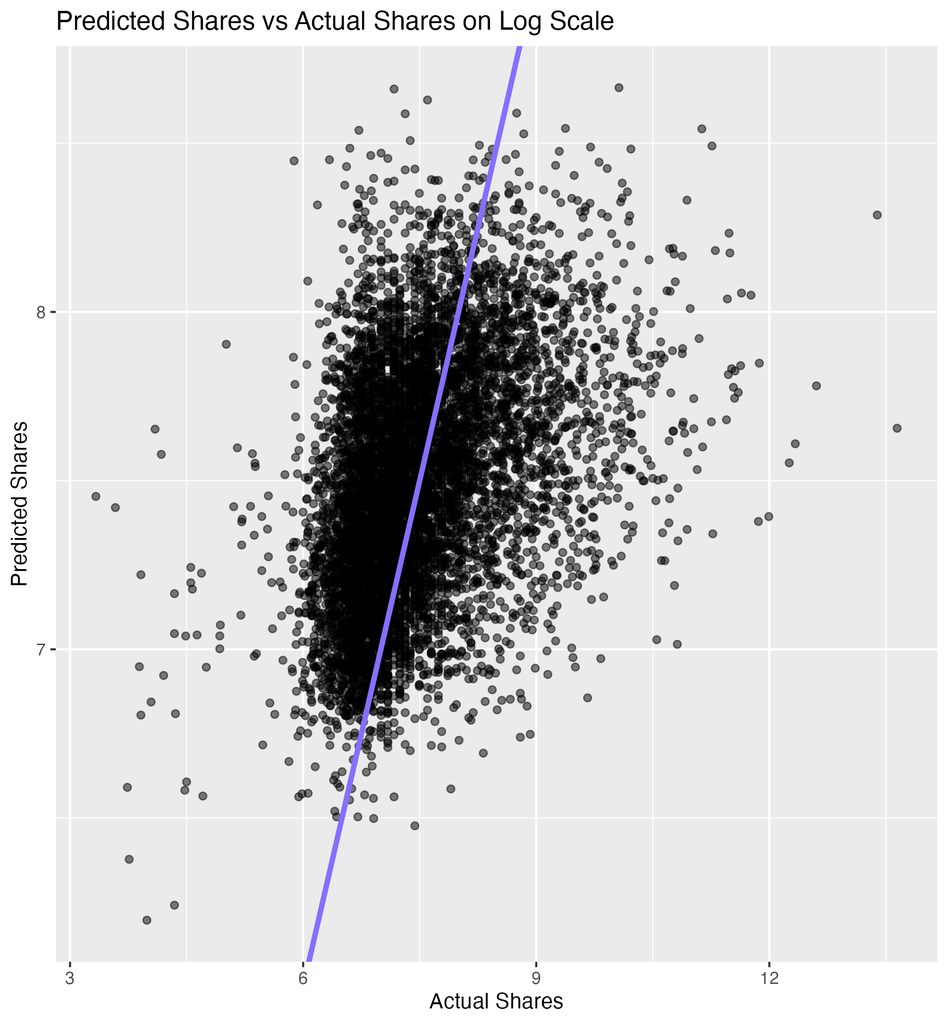

Figure 1: Predicted vs Actual Values on Log Scale

### Metrics on Original Scale

Table 5: Metrics for Final Model on Original Scale

| .metric | .estimator | .estimate |
| --- | --- | --- |
| rmse | standard | 1.488173e+04 |
| rsq | standard | 1.571910e-02 |
| mae | standard | 2.527206e+03 |

According to Table 5, the metrics for the final random forest model on the original scale are an RMSE of 14,881; an RSQ of 0.016, and an MSQ of 2,527.

The RMSE of 14,881 indicates that on average, the predicted values deviate from the actual values by 14,881. Considering that the standard deviation for shares is 11,627; this RMSE values showcases low model success. Ideally, we would want the RMSE to be the same or lower than the standard deviation for the outcome variable.

The RSQ of 0.016 indicates that 1.6% of the variance in shares is explained by the model. This low value means that the model poorly captures the relationship between the predictors and the outcome.

Table 6: Percent of Predicted Values Within 10% of Actual Values on Original Scale

| within_10_pct |
| --- |
| 0.1105927 |

According to Table 6, the model only predicted 11% of values within 10% of the actual values when transformed to original scale. This indicates very low model success.

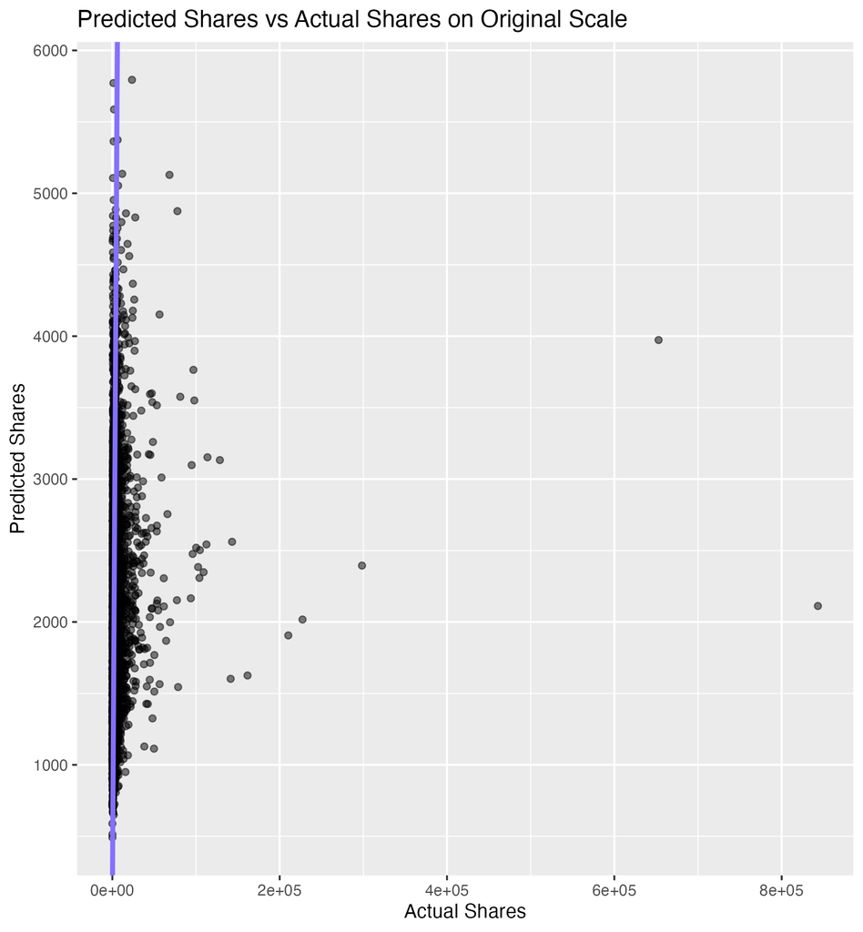

Figure 2: Predicted vs Actual Values on Original Scale

### Final Model vs Baseline Model

When using RMSE as a comparison metric, the final random forest model (`RMSE` = 0.86) performed better than the baseline null model (`RMSE` = 0.928). However, considering the amount of effort that was put into tuning 6 model types, conducting preprocessing recipe steps, and waiting for the models to finish running, the small improvement in the RMSE isn’t significant enough to have made that effort worthwhile.

## Conclusion

Overall, my final random forest model performed slightly better than my baseline null model. Furthermore, while there was an improvement in RMSE between model types, there was not a significant improvement between the kitchen sink recipe and feature engineering recipe. Additionally, although my final model had a low-moderate metrics, when transformed to original scale, it performed poorly, as it only predictied 11% of observations within 10% of the actual value.

In the future, I would conduct a more extensive EDA and put in more research into preprocessing recipe steps to ensure that the recipe steps I include will lead to a more efficient model. Furthermore, I would decrease the values of certain parameters, such as number of variables set at each split, to reduce computational time.

## References

Fernandes, K., Vinagre, P., Cortez, P., & Sernadela, P. (2015). Online News Popularity. UC Irvine Machine Learning Repository. https://archive.ics.uci.edu/dataset/332/online+news+popularity

## Appendix: EDA

### Interactions

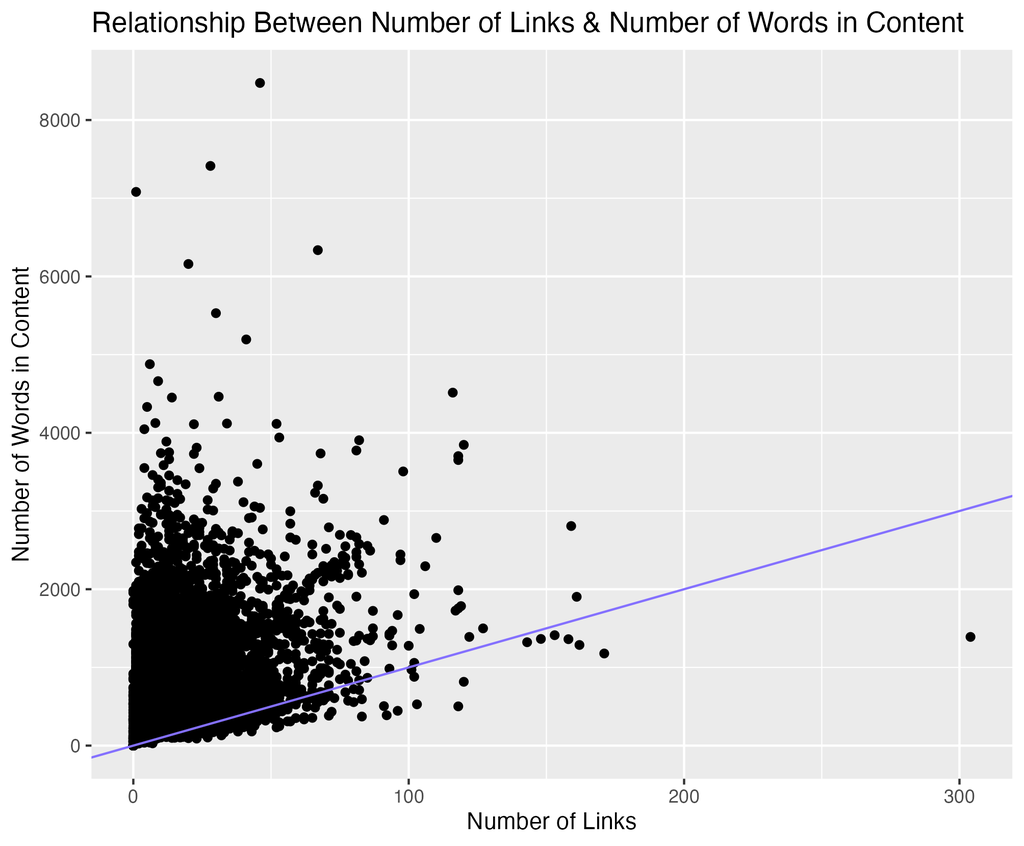

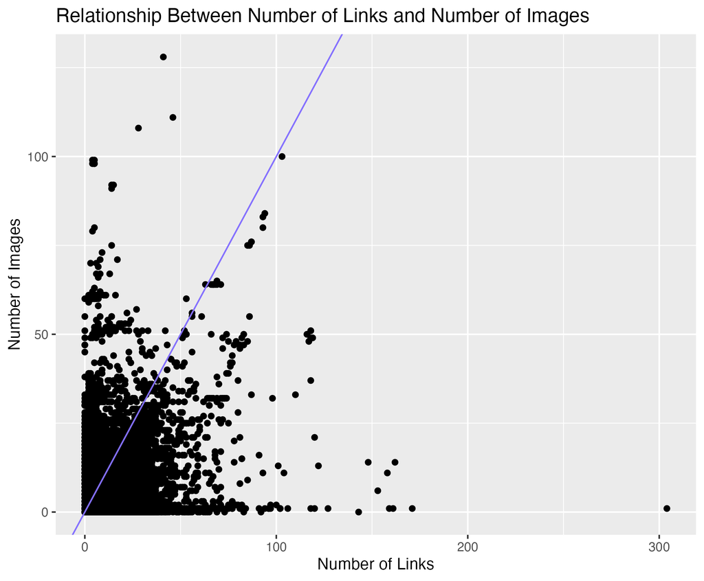

### Natural Splines

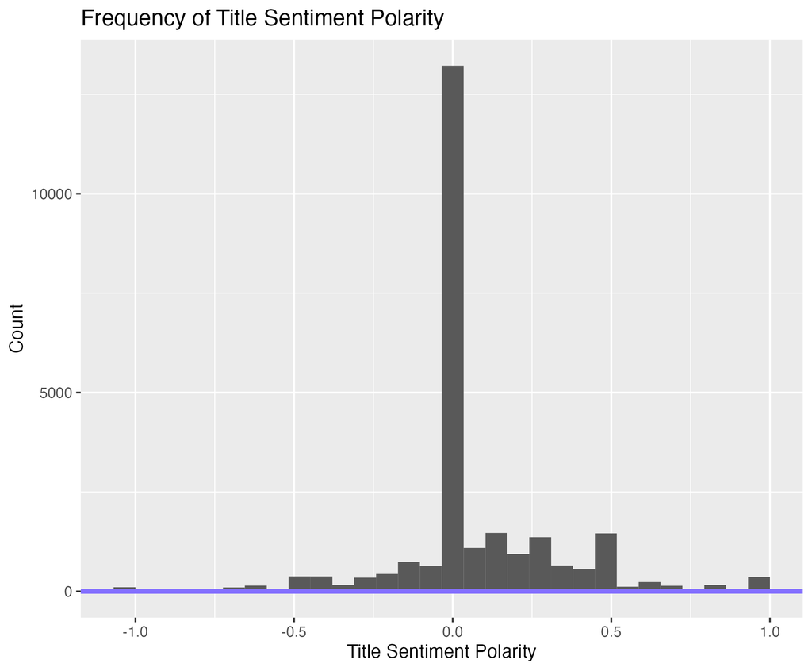

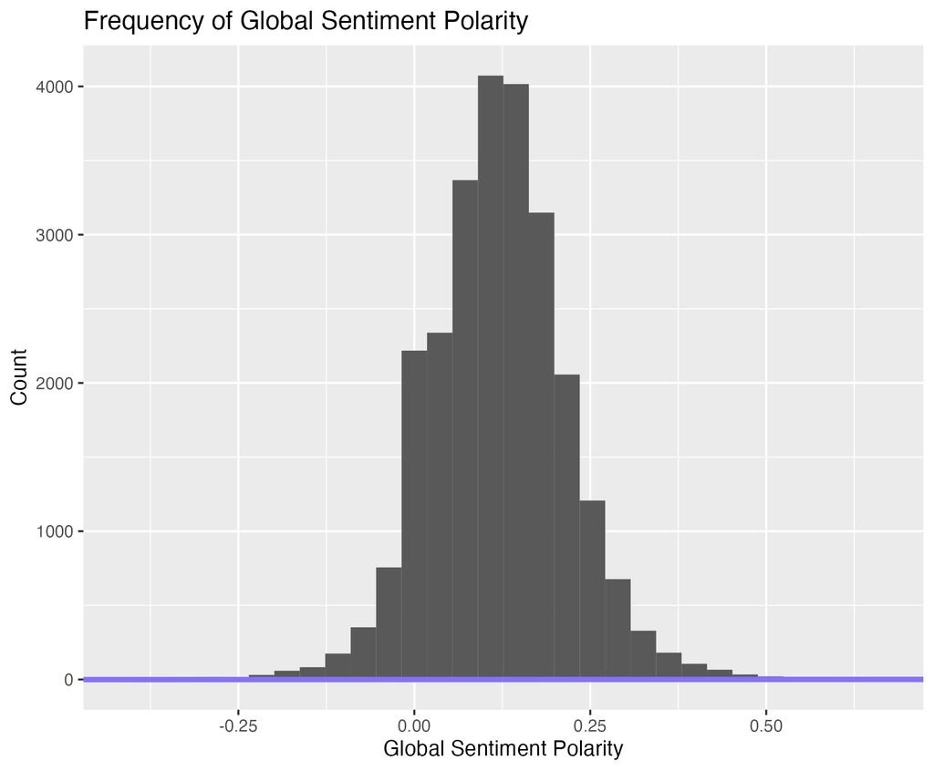

Figure 3: Frequency of Global Sentiment Polarity

Due to these non-linear relationships, I added natural splines to these two variables in my feature engineering recipe.

### Yeo-Johnson

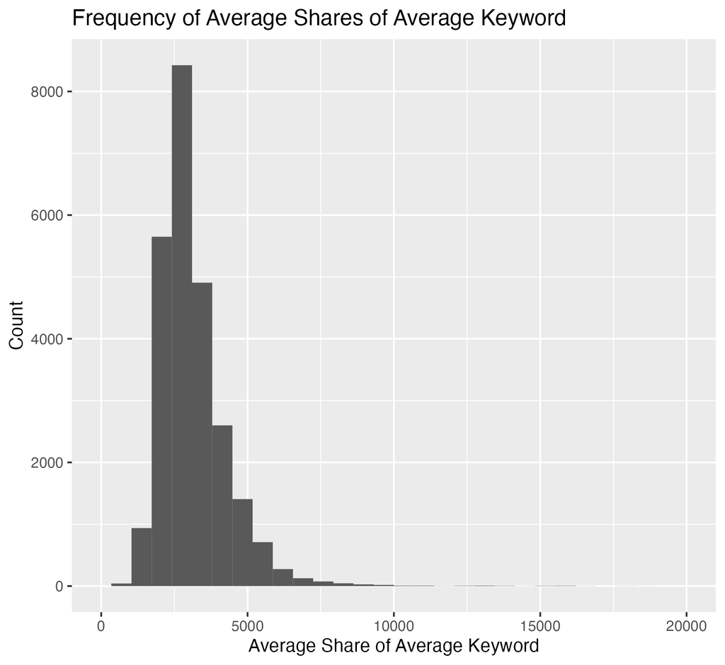

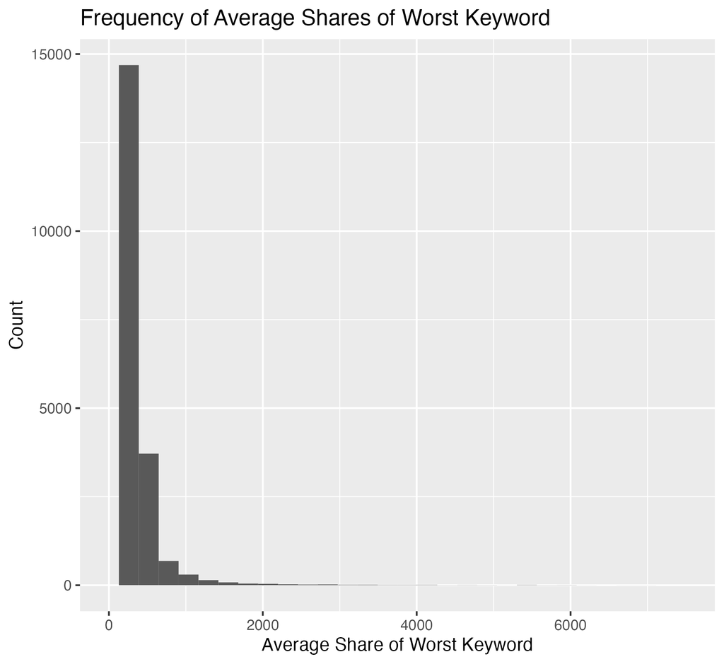

Figure 4: Average Shares of Worst Keyword

As seen in Figure 4, the average shares of worst keywords is right-skewed.

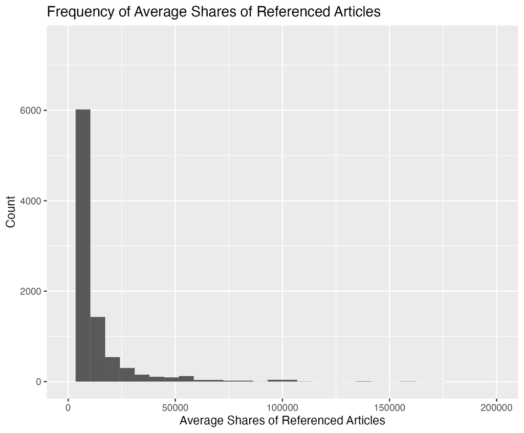

Figure 5: Average Shares of Referenced Articles

As seen in Figure 5, the average shares of referenced articles is right-skewed.

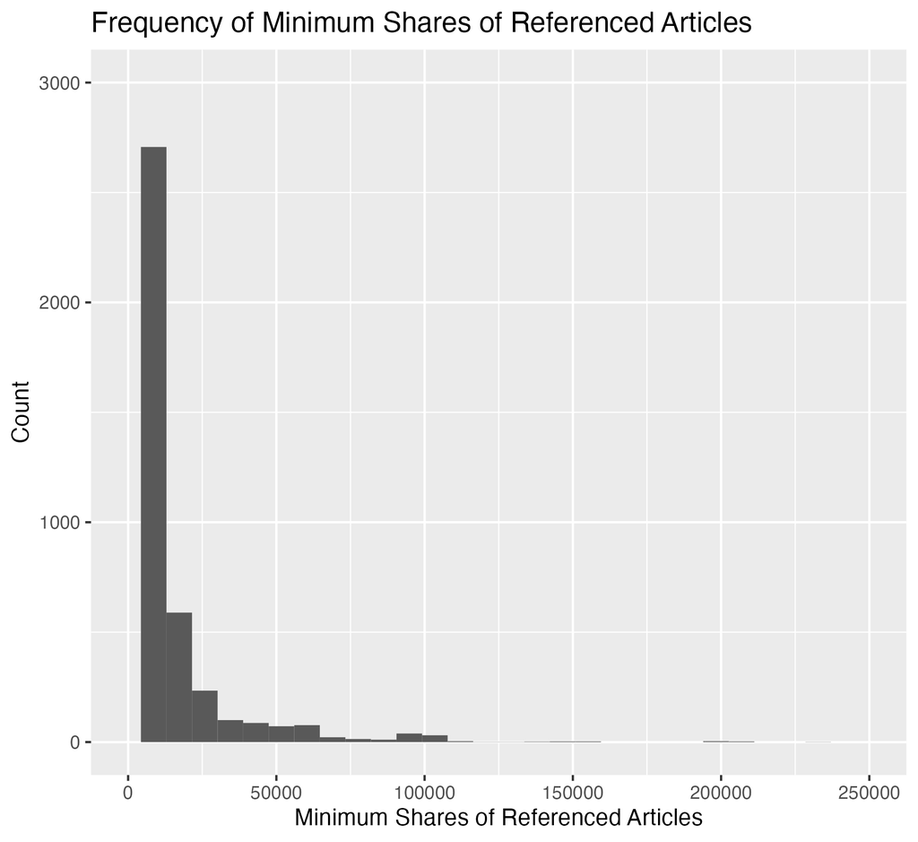

Figure 6: Minimum Shares of Referenced Articles

As seen in Figure 6, the minimum shares of referenced articles is right-skewed.

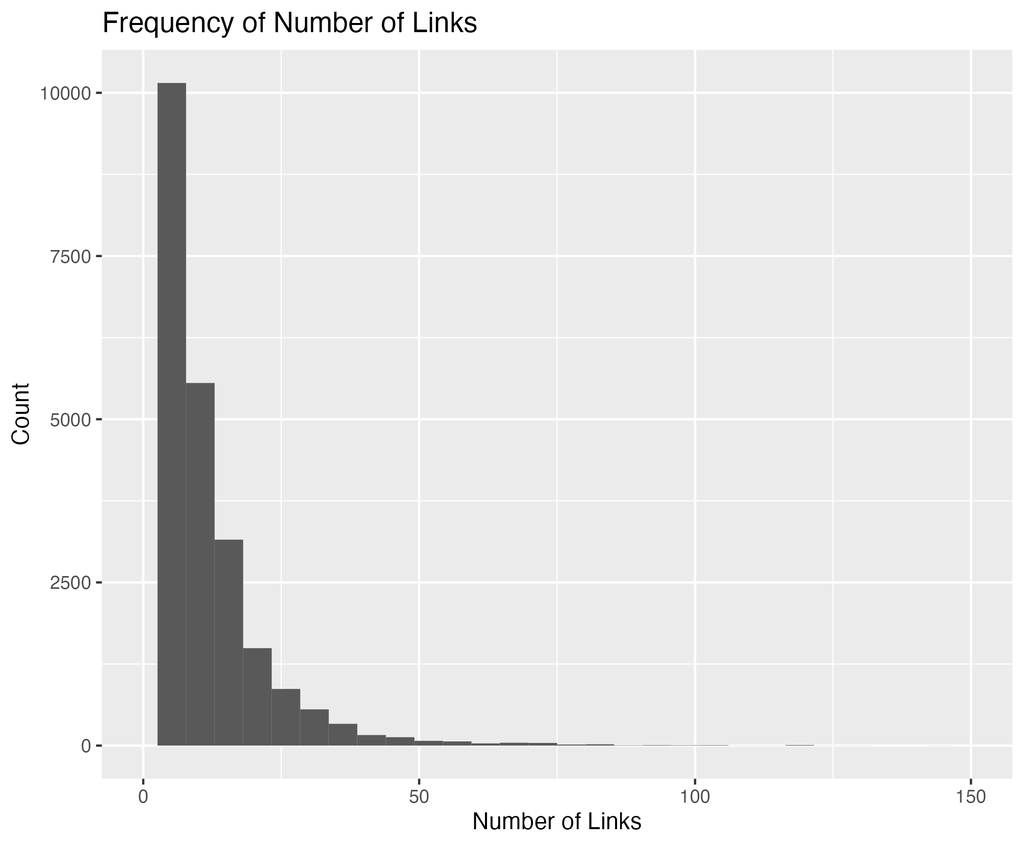

Figure 7: Number of Links

As seen in Figure 7, the frequency of number of links in an article is right-skewed.

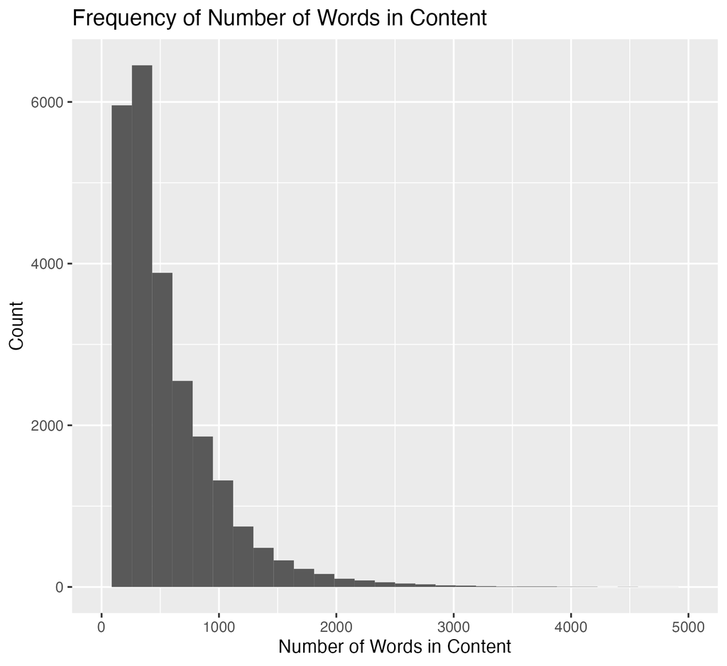

Figure 8: Number of Words in Content

As seen in Figure 8, the frequency of number of words in content is right-skewed.

Since these six variables contain a right-skew, I applied a Yeo-Johnson transformation on them in my feature engineering recipe. I used a Yeo-Johnson transformation instead of a log transformation because the log transformation resulted in the creation of missing values.